# Intro to Statistical Modeling Ch. 6 Prob. 21

Consider the following situation. In order to encourage schools to perform well, a school district hires an external evaluator to give a rating to each school in the district. The rating is a single number based on the quality of the teachers, absenteeism among the teachers, the amount and quality of homeworks the the teachers assign, and so on.

To reward those schools that do well, the district gives a moderate salary bonus to each teacher and a fairly large budget increase to the school itself.

The next year, the school district publishes data showing that the students in schools that received the budget increases had done much better on standarized test scores than the schools that hadn't gotten the increases. The school district argues that this means that increasing budgets overall will improve performance on standardized tests.

The teacher's union supports the idea of higher budgets, but objects to the rating system, saying that it is meaningless and that teacher pay should not be linked to it. The Taxpayers League argues that there is no real evidence that higher spending produces better results. They interpret the school district's data as indicating only that the higher ranked schools are better and, of course, better schools give better results. Those schools were better before they won the ratings-based budget increase.

This is a serious problem. Because of the way the school district collected its data, being a high-rated school is confounded with getting a higher budget.

A modeling technique for dealing with situations like this is called *threshold regression*. Threshold regression models student test scores at each school as a function of the school rating, but includes another variable that indicates whether the school got a budget increase. The budget increase variable is almost the same thing as the school rating: because of the way the school district awarded the increases, it is a threshold transformation of the school rating.

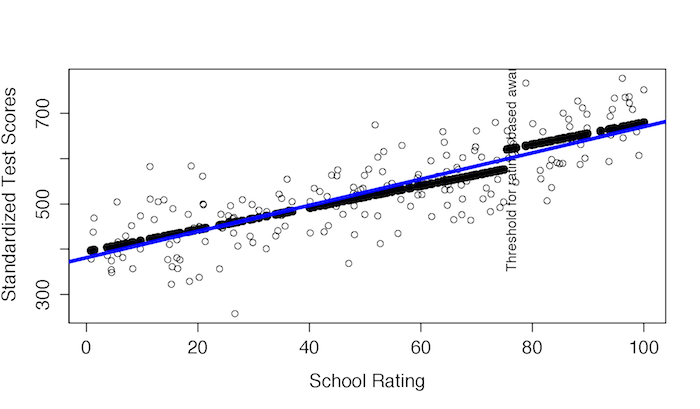

The graph shows some data (plotted as circles) from a simulation of this situation in which the budget increase had a genuine impact of 50 points in the standardized test. The solid line shows the model of test score as a function of school rating, with only the main effect. This model corresponds to the claim that the threshold has no effect. The solid dots are the model values from another model, with rating as a main effect and a threshold transformation of rating that corresponds to which schools got the budget increase.

Explain how to interpret the models as indicating the effect of the budget increase. In addition to your explanation, make sure to give a numerical estimate of how big the effect is, according to the model as indicated in the graph.

An important statistical question is whether the data provide good support for the claim that the threshold makes a difference. (Techniques for answering this question are discussed later in the book). The answer depends both on the size of the effect, and how much data is used for constructing the model. For the simulation here, it turns out that the threshold model has successfully detected the effect of the budget increase.